# Modelos_con_un_algoritmo

José Prince, Andre Jo y Nelson Escalante

2025-04-21

# Proyecto 3 Avances 2 Modelos con un algoritmo

## Enlace a Github

[[https://github.com/Jose-Prince/Proyecto3-Mineria-de-datos]]

## Preprocesamiento de datos

```r
library(rpart)
library(zoo)
library(caret)
library(ranger)

datos <- read.csv("merged_output.csv")

# Define base variables
base_vars <- c("DEPREG", "MUPREG", "MESREG", "AÑOREG", "DIAOCU", "MESOCU", "AÑOOCU", "DEPOCU", "MUPOCU")

# HOM-specific columns
hom_vars <- c(base_vars, "EDADHOM", "PUEHOM", "NACHOM", "ESCHOM", "CIUOHOM")

# MUJ-specific columns
muj_vars <- c(base_vars, "EDADMUJ", "PUEMUJ", "NACMUJ", "ESCMUJ", "CIUOMUJ")

# Create the two dataframes
datos_hom <- datos[, hom_vars]
datos_muj <- datos[, muj_vars]

colnames(datos_hom) <- c(
  base_vars,
  "EDAD", "PUE", "NAC", "ESC", "CIUO"
)

# For datos_muj
colnames(datos_muj) <- c(
  base_vars,
  "EDAD", "PUE", "NAC", "ESC", "CIUO"
)

datos_hom$SEXO <- "HOM"
datos_muj$SEXO <- "MUJ"

datos <- rbind(datos_hom, datos_muj)
```

## Variable Respuesta

De acuerdo con nuestros objetivos y la problemática, decidimos utilizar la variable cuantitativa edad tanto de la mujer como del hombre debido a que es un factor clave para entender los patrones y características del divorcio en Guatemala. La edad nos permite analizar en qué etapas de la vida ocurren con mayor frecuencia los divorcios, identificar posibles diferencias entre hombres y mujeres, y explorar si existe una relación entre la edad y la probabilidad de disolución del matrimonio. Por lo tanto, decidimos realizar transformaciones en los datos, unificando las edades de la mujer y del hombre en una sola variable denominada edad. Asimismo, se integró la etnia de ambos en una única variable, con el objetivo de evitar discrepancias al momento del análisis y facilitar la comparación entre ambos géneros.

Por otro lado existen datos NA como el año de ocurrencia con las datos que tienen como registro en 2012 ya que no sabemos si ocurrieron en el año anterior o anteriores lo cual lo generalizamos como el año 2012. Por otro lado en nuestra variable respuesta tiene muchos valores NA lo cual no podemos aplicar llenado de datos con la mediana. Por lo tanto utilizamos un algoritmo forward y backward filling para Completar valores faltantes de forma sencilla cuando se espera que los datos no cambien drásticamente de un punto a otro.

```
##     DEPREG             MUPREG              MESREG           AÑOREG
##  Length:163652      Length:163652      Min.   : 1.000   Min.   :2012
##  Class :character   Class :character   1st Qu.: 4.000   1st Qu.:2015
##  Mode  :character   Mode  :character   Median : 7.000   Median :2019
##                                        Mean   : 6.546   Mean   :2018
##                                        3rd Qu.:10.000   3rd Qu.:2022
##                                        Max.   :12.000   Max.   :2024
##      DIAOCU          MESOCU           AÑOOCU        DEPOCU
##  Min.   : 1.00   Min.   : 1.000   Min.   :2012   Length:163652
##  1st Qu.: 8.00   1st Qu.: 3.000   1st Qu.:2015   Class :character
##  Median :16.00   Median : 6.000   Median :2019   Mode  :character
##  Mean   :15.78   Mean   : 6.305   Mean   :2018
##  3rd Qu.:23.00   3rd Qu.: 9.000   3rd Qu.:2021
##  Max.   :31.00   Max.   :12.000   Max.   :2023
##     MUPOCU               EDAD           PUE                NAC
##  Length:163652      Min.   :15.00   Length:163652      Length:163652
##  Class :character   1st Qu.:29.00   Class :character   Class :character
##  Mode  :character   Median :35.00   Mode  :character   Mode  :character
##                     Mean   :37.82
##                     3rd Qu.:44.00
##                     Max.   :98.00
##      ESC                CIUO               SEXO
##  Length:163652      Length:163652      Length:163652
##  Class :character   Class :character   Class :character
##  Mode  :character   Mode  :character   Mode  :character
##
##
##
```

```
## [1] 163652     15
```

Para el conjunto de prueba y entrenamiento observamos que el data set esta ordenado por años, lo cual nuestro proposito es construir un modelo cuyo proposito es predecir en los futuros años. Por lo tanto se tomara para el conjunto de entrenamiento todos los datos que tienen un año de registro menor o igual que 2021. Para los datos de prueba se utilizaria año de registro mayores a 2021.

```
##      DEPREG      MUPREG MESREG AÑOREG DIAOCU MESOCU AÑOOCU        DEPOCU
## 1 Guatemala   Guatemala      8   2015     17      7   2015 Huehuetenango
## 2 Guatemala   Guatemala      6   2016     29      7   2015     Guatemala
## 3    Zacapa      Zacapa      2   2016      8      7   2015        Zacapa
## 4 Guatemala   Guatemala      2   2016     22     12   2015     Guatemala
## 5   Jutiapa Agua Blanca      2   2015      3      2   2015       Jutiapa
## 6 Guatemala   Guatemala      6   2016     14     10   2015       Jutiapa
##          MUPOCU EDAD              PUE            NAC     ESC     CIUO SEXO
## 1 Huehuetenango   46         Ignorado      Guatemala Ninguno Ignorado  HOM
## 2     Guatemala   46         Ignorado Estados Unidos Ninguno Ignorado  HOM
## 3        Zacapa   46 Mestizo / Ladino      Guatemala Ninguno Ignorado  HOM
## 4   Villa Nueva   46         Ignorado      Guatemala Ninguno Ignorado  HOM
## 5  Yupiltepeque   46 Mestizo / Ladino      Guatemala Ninguno Ignorado  HOM
## 6       Jutiapa   46         Ignorado      Guatemala Ninguno Ignorado  HOM
```

```
##             DEPREG                MUPREG MESREG AÑOREG DIAOCU MESOCU AÑOOCU
## 46342    Guatemala             Guatemala      6   2022     23      8   2021
## 46344    Guatemala             Guatemala      1   2022     29     11   2021
## 46351 Alta Verapaz San Cristobal Verapaz      1   2022     23      8   2021
## 46356    Guatemala             Guatemala      4   2022     15     11   2021
## 46372    Guatemala             Guatemala      1   2022     19     11   2021
## 46375    Guatemala             Guatemala      1   2022     26     11   2021
##             DEPOCU                MUPOCU EDAD              PUE       NAC
## 46342    Guatemala             Guatemala   36 Mestizo / Ladino Guatemala
## 46344    Guatemala             Guatemala   48 Mestizo / Ladino Guatemala
## 46351 Alta Verapaz San Cristobal Verapaz   27             Maya Guatemala
## 46356    Guatemala             Chinautla   58 Mestizo / Ladino Guatemala
## 46372    Guatemala             Guatemala   51 Mestizo / Ladino Guatemala
## 46375    Guatemala             Guatemala   43 Mestizo / Ladino Guatemala
##                 ESC     CIUO SEXO
## 46342 Universitario Ignorado  HOM
## 46344 Universitario Ignorado  HOM
## 46351      Primaria Ignorado  HOM
## 46356 Universitario Ignorado  HOM
## 46372 Universitario Ignorado  HOM
## 46375 Universitario Ignorado  HOM
```

```
## [1] 36.75274
```

Se observa que el porcentaje del conjunto de prueba es de 36.75% mientras que el porcentaje de entrenamiento es de 63.25

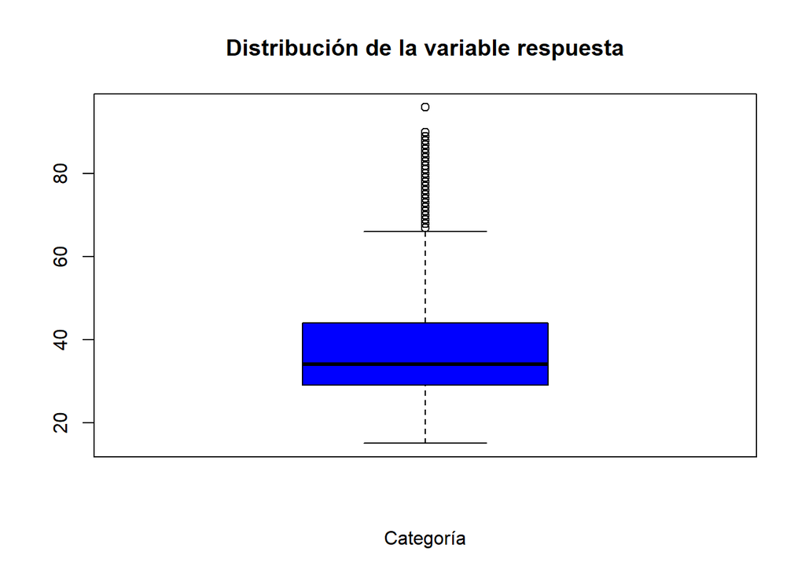

Se observa que en la caja de bigotes que los datos atípicos en el conjunto de entrenamientos son las personas mayores a 65 años. Estas podrían representar valores atípicos porque tiene una menor ocurrencia de estos valores en la muestra.

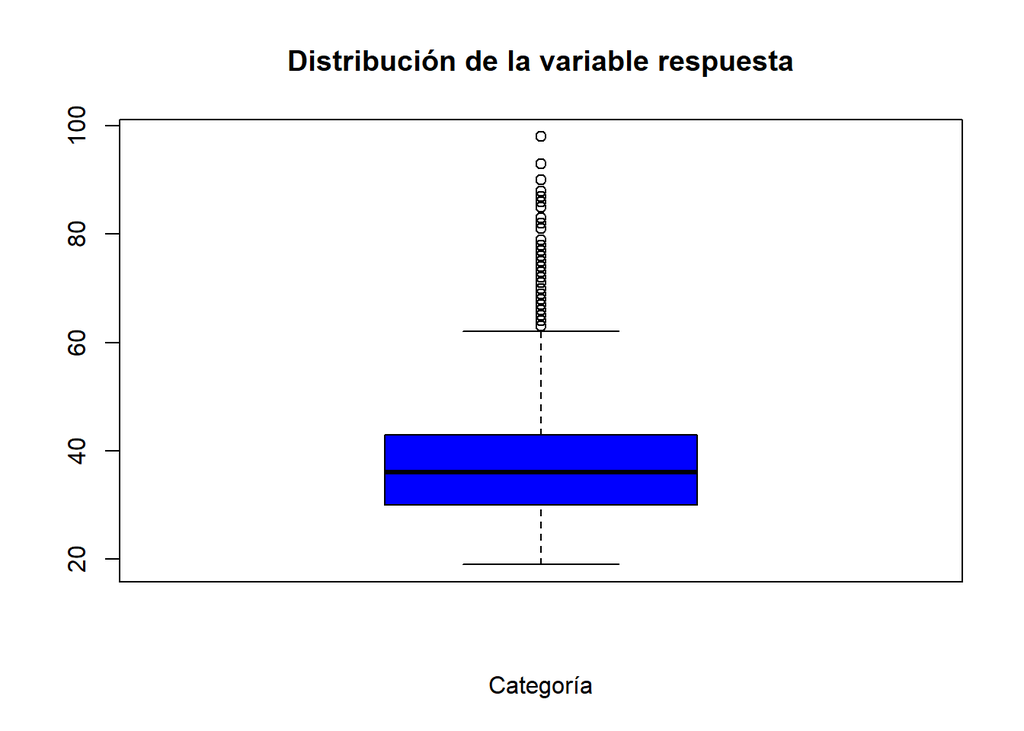

Por otro lado observamos que acá los datos atipicos son identificados al tener 62 años o más. Estas podrían representar valores atípicos o simplemente una menor ocurrencia de estos valores en la muestra.

## Modelos de Random Forest

Para el analisis se utilizara el algoritmo de random forest, debido a su buena capacidad para predecir utilizando varias variables descriptivas. Para el uso correcto de este algoritmo, se deben guardar las variables categoricas como factores, limpiar las columnas con NA y dividir el conjunto de datos. Al realizar todo el preprocesamiento indicado, nos aseguramos de que los modelos funcionan para analizar nuestro conjunto de datos.

```
## [1] "RMSE del Modelo ranger 1 en prueba: 9.85143660647537"
```

```
## [1] "RMSE del Modelo ranger 2 en prueba: 9.82141467359911"
```

```
## [1] "RMSE del Modelo ranger 3 en prueba: 9.80603416394606"
```

```
## [1] "El mejor modelo en el conjunto de prueba es: ranger 3 con un RMSE de: 9.80603416394606"
```

```
## [1] "El mejor modelo final entrenado con parámetros manuales:"
```

```
## Ranger result
##
## Call:
##  ranger(EDAD ~ ., data = entrenamiento[, c(variable_respuesta,      variables_predictoras)], num.trees = 150, mtry = 3, min.node.size = 15,      splitrule = "variance", importance = "impurity")
##
## Type:                             Regression
## Number of trees:                  150
## Sample size:                      114558
## Number of independent variables:  14
## Mtry:                             3
## Target node size:                 15
## Variable importance mode:         impurity
## Splitrule:                        variance
## OOB prediction error (MSE):       97.19678
## R squared (OOB):                  0.3865799
```

```
##
## Explicación de la selección del mejor modelo:
```

```
## Para seleccionar el mejor modelo, creamos tres modelos de Random Forest utilizando el algoritmo 'ranger' con las siguientes combinaciones de parámetros definidas manualmente:
```

```
## - Modelo ranger 1: num.trees = 100, mtry = 5, min.node.size = 5, splitrule = 'variance'
```

```
## - Modelo ranger 2: num.trees = 200, mtry = 8, min.node.size = 10, splitrule = 'variance'
```

```
## - Modelo ranger 3: num.trees = 150, mtry = 3, min.node.size = 15, splitrule = 'variance'
```

[output not shown]

```
## Los RMSE obtenidos en el conjunto de prueba para cada modelo fueron:
```

```
## - Modelo ranger 1: RMSE = 9.8514
```

```
## - Modelo ranger 2: RMSE = 9.8214
```

```
## - Modelo ranger 3: RMSE = 9.806
```

```
## Seleccionamos el modelo con el menor RMSE en el conjunto de prueba como el mejor modelo final, ya que indica que este modelo tuvo el mejor rendimiento en la predicción de la variable 'EDAD' en datos no vistos. En este caso, el mejor modelo fue: ranger 3 con un RMSE de: 9.806 .
```

```
## Los parámetros de este mejor modelo final son:
```

```
## ranger(EDAD ~ ., data = entrenamiento[, c(variable_respuesta,
##     variables_predictoras)], num.trees = 150, mtry = 3, min.node.size = 15,
##     splitrule = "variance", importance = "impurity")
```

Para seleccionar el mejor modelo, creamos tres modelos de Random Forest utilizando el algoritmo ‘ranger’ con las siguientes combinaciones de parámetros definidas manualmente: - Modelo ranger 1: num.trees = 100, mtry = 5, min.node.size = 5, splitrule = ‘variance’ - Modelo ranger 2: num.trees = 200, mtry = 8, min.node.size = 10, splitrule = ‘variance’ - Modelo ranger 3: num.trees = 150, mtry = 3, min.node.size = 15, splitrule = ‘variance’

Evaluamos el rendimiento de cada modelo directamente en el conjunto de prueba utilizando el RMSE (Root Mean Squared Error). El conjunto de prueba contiene datos que el modelo no vio durante el entrenamiento, por lo que su rendimiento en este conjunto es una buena indicación de cómo generalizará a datos futuros.

Para seleccionar el mejor modelo, creamos tres modelos de Random Forest utilizando el algoritmo ‘ranger’ con las siguientes combinaciones de parámetros definidas manualmente: - Modelo ranger 1: num.trees = 100, mtry = 5, min.node.size = 5, splitrule = ‘variance’ - Modelo ranger 2: num.trees = 200, mtry = 8, min.node.size = 10, splitrule = ‘variance’ - Modelo ranger 3: num.trees = 150, mtry = 3, min.node.size = 15, splitrule = ‘variance’

Evaluamos el rendimiento de cada modelo directamente en el conjunto de prueba utilizando el RMSE (Root Mean Squared Error). El conjunto de prueba contiene datos que el modelo no vio durante el entrenamiento, por lo que su rendimiento en este conjunto es una buena indicación de cómo generalizará a datos futuros.